# numerical integration; more on random numbers; Game of Life

Ben Bolker

19 November 2019

## numerical integration

In first year calculus the definite integral of a function $f(x)$ over the interval $[a, b]$ is defined to be the limit of a sequence of *Riemann sums*:
$$\int_a^b f(x)\, dx = \lim_{n \to \infty} \sum_{i=0}^{n-1} f(x_i) \, \Delta x$$
where $\Delta x = (b - a)/n$ and $x_i = a + i \cdot \Delta x$ - So the definite integral can be approximated using Riemann sums for suitably large values of $n$

## coding Riemann sums in numpy

```python
import numpy as np
def num_int(f, a, b, n):
   dx = (b-a)/n
   x = np.arange(a, b, step = dx)
   y = f(x)
   return y.sum() * dx
```

Note this takes a *function* `f` as input.

## example

Try approximating $\int_0^1 x^2 \, dx$ with $n=\{10,50,5000\}$

```python
def x_squared(x):
   return x ** 2
approx1 = num_int(x_squared, 0, 1, 10)
approx2 = num_int(x_squared, 0, 1, 50)
approx3 = num_int(x_squared, 0, 1, 5000)
print(approx1, approx2, approx3)
```

```
## 0.2850000000000001 0.3234 0.33323334
```

We could create an *adaptive* version of this that keeps trying larger values of `n` until the results are “close enough”

## refinements

- `num_int` uses the *left endpoint* rule to compute Riemann sums for a function $f(x)$
- In Section 7.7 of Dr. Stewart’s Calculus textbook, several other methods are presented.
- The *right endpoint* and *midpoint* rules are simple variations of the left endpoint rule:

$$\begin{split}
\int_a^b f(x)\, dx & = \lim_{n \to \infty} \sum_{i=0}^{n-1} f(x_{i+1}) \, \Delta x \qquad \textrm{right endpoint} \\
\int_a^b f(x)\, dx & = \lim_{n \to \infty} \sum_{i=0}^{n-1} f\left((x_i+x_{i+1})/2\right) \, \Delta x \qquad \textrm{midpoint}
\end{split}$$

## other rules

- **trapezoid rule**: use the average of the approximations obtained by using the left and right endpoint rules
- **Simpson’s method**: use quadratic functions (parabolas) instead of linear functions to interpolate
  $$\int_a^b f(x)\, dx \approx \sum (\Delta x/6)\left(f(x_i) + 4f((x_i+x_{i+1})/2) +f(x_{i+1})\right)$$

We’ll write a function that implements any of these rules, and check it with $\int_0^1 x^2 \, dx$ and $\int_0^1 x^3 \, dx$.

## symbolic integration

```python
from sympy import *
x = Symbol('x')
integrate(x**2,x) ## no "plus a constant"
```

```
## x**3/3
```

Or definite integrals:

```python
integrate(x**2,(x,0,1))
```

```
## 1/3
```

But:

```python
integrate(log(x)**x,x)
```

```
## Integral(exp(x*log(log(x))), x)
```

(see [Wikipedia](https://en.wikipedia.org/wiki/Risch_algorithm) for more information on symbolic integration)

## area of a circle

```python
integrate(sqrt(1-x**2),x)
```

```
## x*sqrt(-x**2 + 1)/2 + asin(x)/2
```

```python
integrate(sqrt(1-x**2),(x,0,1))
```

```
## pi/4
```

- Let’s try it with the integrator from above

## Monte Carlo integration

- “Monte Carlo” in general refers to **any** algorithm that uses (pseudo) random numbers
- a Monte Carlo method to approximate $\pi$:
- draw a square of area 1
- inscribe a quarter circle (with radius = 1)
- the area $A$ of the quarter-circle is equal to $\pi/4$
- randomly throw darts in the square and count the number of them that fall within the circle (i.e. $x^2+y^2<1$)
- the ratio of the number that fall into the circle to the total number thrown should be close to the ratio of the area of the circle to the area of the square
- the more darts thrown, the better the approximation.
- `numpy.linspace(start,stop,num, endpoint=True)` is a more convenient way to generate evenly (linearly) spaced values
- by default it includes the endpoint (unlike `numpy.arange()`)

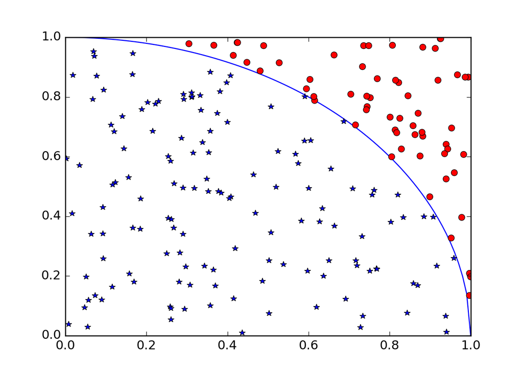

```python
import matplotlib.pyplot as plt
import numpy.random as npr
x = np.linspace(0,1,101)
y = np.sqrt(1-x**2)
fig, ax = plt.subplots()
ax.plot(x,y)
xr = npr.uniform(size=200)
yr = npr.uniform(size=200)
incirc = xr**2+yr**2<1
ax.plot(xr[incirc],yr[incirc],"b*")
ax.plot(xr[np.logical_not(incirc)],yr[np.logical_not(incirc)],"ro")
```

## continuing

- now we just have to count the number

```python
from math import pi
incirc.mean()*4/pi
```

```
## 0.884901483590938
```

## another example

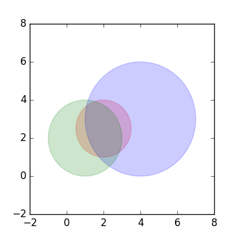

```python
import numpy.random as npr
import numpy as np
c = ((2,2.5),(4,3),(1,2))
r = (1.5,3,2)
npr.seed(101)
x = npr.uniform(c[0][0]-r[0],c[0][0]+r[0],size=1000000)
y = npr.uniform(c[0][1]-r[0],c[0][1]+r[0],size=1000000)
tests = np.tile(True,10**6)  ## boolean vector
def incirc(x,y,ctr,radius):
    dsq = (x-ctr[0])**2+(y-ctr[1])**2
    return(dsq<radius**2)
for c0,r0 in zip(c,r):       ## zip() rearranges lists
    tests = tests & incirc(x,y,c0,r0)
    print(np.mean(tests))
```

```
## 0.78613
## 0.658081
## 0.48976
```

```python
print(r[0]**2*np.mean(tests))
```

```
## 1.10196
```

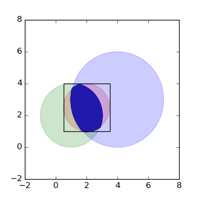

## More on random number generation

## (Pseudo)random numbers

- From [Wikipedia](http://en.wikipedia.org/wiki/Pseudorandom_number_generator): “Anyone who considers arithmetical methods of producing random digits is, of course, in a state of sin” (von Neumann) ([original paper](https://dornsifecms.usc.edu/assets/sites/520/docs/VonNeumann-ams12p36-38.pdf)) … “We are here dealing with mere ‘cooking recipes’ for making digits; probably they can not be justified, but should merely be judged by their results …”

## linear congruential generators

- $x_n = (a x_{n-1} + c) \textrm{mod} m$
- or `x = (a*x +c ) % m`
- from [here](http://www.eternallyconfuzzled.com/tuts/algorithms/jsw_tut_rand.aspx):

Simple example:

```python
x = [5]         ## starting value
a,c,m = 2,3,10  ## constants
for i in range(9):
    newx = (a*x[-1]+c) % m
    x.append(newx)
print(x)
```

```
## [5, 3, 9, 1, 5, 3, 9, 1, 5, 3]
```

## Park-Miller *minimal standard generator*

```python
a,c,m = 16807,0,2147483647
x = [5]
for i in range(9):
    newx = (a*x[-1]+c) % m
    x.append(newx)
print(np.array(x)/m)
```

```
## [2.32830644e-09 3.91318463e-05 6.57688941e-01 7.78026611e-01
##  2.93250660e-01 6.63836187e-01 9.47959316e-02 2.35223081e-01
##  3.94323584e-01 3.96482029e-01]
```

## run for longer

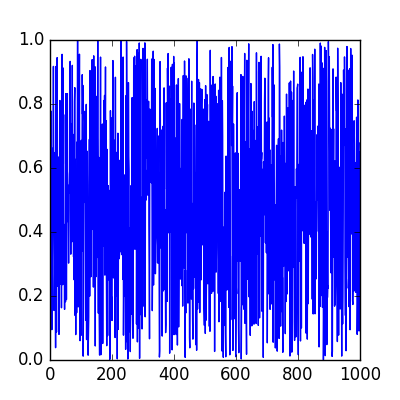

random values

- using `numpy`: [reference](http://docs.scipy.org/doc/numpy/reference/routines.random.html)

```python
import numpy.random as npr
a = npr.rand(1000)
```

- can also do useful things like
  - pick from a list: `choice()` (with or without replacement)
  - shuffle values: `shuffle()` (in-place)
  - pick values from different distributions
  - sample from a large range of non-uniform distributions (Poisson, Normal, binomial …)
- using random number generators for serious work:
  - know what generator is used
    - [Mersenne twister](https://en.wikipedia.org/wiki/Mersenne_Twister): period of $2^{219937} - 1$, very widely used
  - set the seed: `seed()`
- using random numbers for cryptography: be super-paranoid: see e.g. [this](http://stackoverflow.com/questions/20936993/how-can-i-create-a-random-number-that-is-cryptographically-secure-in-python)

## pieces

- `life_init(size, init_dens)`: set up a `size*size` 2D array of zeros; set a density `init_dens` to 1
- `life_step(w,nw)`: run the Conway rules on an array `w` and return the new array `nw`
- `count_nbr(w,i,j)`: count the number of neighbours in the 3x3 square around `w[i,j]`
- `life_show(w, ax)`: plot an image of the current array `w` on axes `ax`

## examples

```python
import os
import matplotlib.pyplot as plt
os.chdir("../code")
from life import *
os.chdir("../notes")
w = life_init()
fig, ax = plt.subplots()
life_show(w, ax)
fig.savefig("pix/life1.png")
```

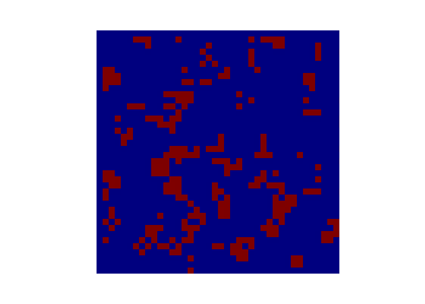

```python
nw = w.copy()
(nw, w) = life_step(w,nw)
life_show(w, ax)
fig.savefig("pix/life2.png")
```

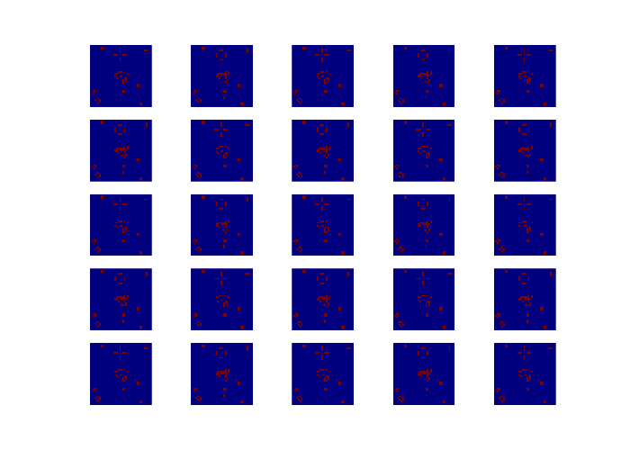

```python
fig, ax = plt.subplots(5,5)
for i in range(ax.shape[0]):
    for j in range(ax.shape[1]):
        nw, w = life_step(w,nw)
        life_show(w, ax[i][j])
fig.savefig("pix/life3.png")
```

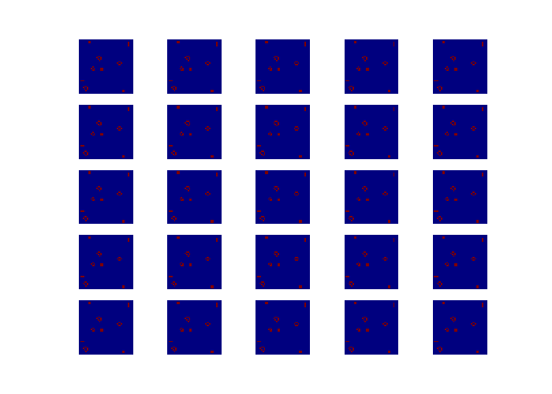

```python
fig, ax = plt.subplots(5,5)
for i in range(ax.shape[0]):
    for j in range(ax.shape[1]):
        for k in range(10):
            life_show(w, ax[i][j])
            nw, w = life_step(w,nw)
fig.savefig("pix/life4.png")
```